# Volpe R Course: Session 3, Data Exploration

Instructors: Don Fisher, Dan Flynn, Jessie Yang  
Course webpage: http://bit.ly/volpeR

9/19/2017

# Overview

### Last session:

- Writing functions
- Writing loops

### Today: Data exploration

- Aggregating data
- Matching
- Basic data analysis
- Saving work and sharing

# Homework

*Quick review of some of your solutions!*

### Loops

Write a loop to perform some task on your data.

```r
indexvec <- vector()

for(indexvalue in 1:15){
  indexvec <- c(indexvec,
 sample(homework2$Numeric1,size=1))
}

indexvec
```

### Functions

Write a function to perform some task on your data.

```r
GradeServ <- function(emp){
  mg <- mean(emp$Grade)
  ms <- mean(emp$Years.Of.Service)
  c(mg, ms)
}
GradeServ(emp)
```

# Data exploration

Read in the Hubway data from the course page. We will use this data on Hubway bike-share trips (from https://www.thehubway.com/system-data) to demonstrate first steps in exploring a new data set (with all the issues that real-world data often have!).

Read in the data, after downloading to your H: drive:

```r
setwd("H:/R")

d <- read.csv("Hubway_Sample.csv")

head(d)
```

```
##   tripduration     starttime      stoptime start.station.id
## 1          370 7/1/2016 0:00 7/1/2016 0:07               39
## 2          211 7/1/2016 0:01 7/1/2016 0:04               60
## 3          720 7/1/2016 0:01 7/1/2016 0:13               36
## 4          720 7/1/2016 0:01 7/1/2016 0:13               36
## 5          445 7/1/2016 0:01 7/1/2016 0:08               36
## 6          320 7/1/2016 0:02 7/1/2016 0:07               26
##                              start.station.name start.station.latitude
## 1                 Washington St. at Rutland St.               42.33849
## 2 Charles Circle - Charles St. at Cambridge St.               42.36062
## 3      Boston Public Library - 700 Boylston St.               42.34967
## 4      Boston Public Library - 700 Boylston St.               42.34967
## 5      Boston Public Library - 700 Boylston St.               42.34967
## 6                 Washington St. at Waltham St.               42.34152
##   start.station.longitude end.station.id
```

[output cut: 27 more lines]

# Aggregating data

Aggregating data is done most often with these functions: `aggregate`, `tapply`, and `apply`.

Use `aggregate` to make two-way (or more) summary tables:

```r
aggregate(d$tripduration,
          by = list(d$birth.year, d$gender), FUN = mean)
```

Use `tapply` to make one-way summary tables:

```r
tapply(d$tripduration, d$gender, mean)
```

# Aggregating data

Use apply to look across multiple columns or rows:

```r
apply(d[6:7],     # data frame to look at (should be two-dimensional)
      2,                  # 1 is for rows, 2 is for columns
      mean)               # Function
```

# Aggregating data

For these data, the start and stop time should be read in as a `datetime` class vectors, which have different properties from character or factor vectors. Use the `strptime` function to convert to `datetime` class, which in R is called POSIXlt.

```r
class(d$starttime)
```

```
## [1] "factor"
```

```r
d$starttime[1]
```

```
## [1] 7/1/2016 0:00
## 33764 Levels: 7/1/2016 0:00 7/1/2016 0:01 7/1/2016 0:02 ... 7/9/2016 9:59
```

```r
# Pay attention to the capitalization!
d$starttime <- strptime(d$starttime, format = "%m/%d/%Y %H:%M")
class(d$starttime)
```

```
## [1] "POSIXlt" "POSIXt"
```

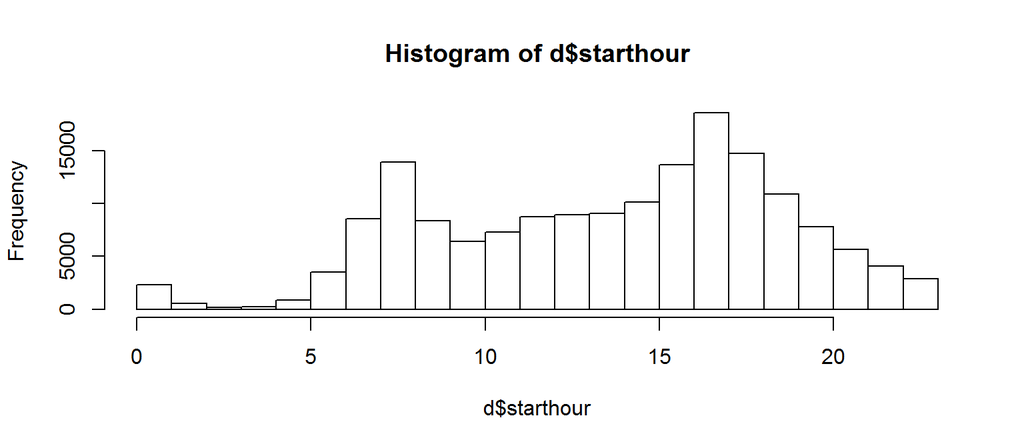

```r
# Create starthour
d$starthour <- as.numeric(format(d$starttime, "%H"))
hist(d$starthour) # see the clear peaks for communiting times.
```

# Aggregating data

Let’s aggregate the trip duration by the new variable start hour and by gender.

```r
# Two index vectors, using aggregate
aggregate(d$tripduration,
          by = list(d$starthour, d$gender), FUN = mean)
```

### Exercise:

Create a table of average trip duration by *month* of the year.

Hint: look at `?strptime` for format ideas

#### Optional advanced exercise:

Carry out a statistical test to assess if trip duration differs by month of the year. Do you format *month* as a factor or a numeric variable? Which test would you use to assess that?

# Matching and merging

Matching is a powerful tool to work with character strings, and comes in handy for both cleaning data and creating subsets of data. The most common functions are:

- `grep` to find the elements that partially match one input
- `sub` to find and change the elements that match one input
- `match` to find the elements that match a vector of inputs

```r
boylston.stations <- grep("Boylston", d$start.station.name)

length(boylston.stations)
```

```
## [1] 14677
```

```r
length(boylston.stations) / nrow(d)
```

```
## [1] 0.08768408
```

```r
# make a subset based on this search:

db <- d[boylston.stations,]
dim(db)
```

```
## [1] 14677    16
```

# Regular expressions

The use of `grep` above is an example of *regular expression*. These are very flexible and form the basis for all search engines. In R, there are number of ways to use regular expressions, with `grep` and `sub` being two of the most common ones. `regexpr` also provides additional options for those familiar with Perl or Python.

```r
text1 <- c("Testing", "matching ", " and substitutions")
sub(" +$", "", text1) # find and replace trailing whitespace
```

```
## [1] "Testing"            "matching"           " and substitutions"
```

```r
grep("^ ", text1) # find elements which start with a whitespace
```

```
## [1] 3
```

```r
grep("^[A-Z]", text1) # find elements which start with a capital letter
```

```
## [1] 1
```

# Merging data frames

Merging data between different sources requires having a common column name or row name. The two functions most often used are `merge` and `match`. Type the following:

```r
example(merge)
authors
books

merge(authors, books, by.x = "surname", by.y = "name")
# and do it again again, adding `all.y = TRUE`
```

We can use match to carry out a similar operation. `match` is more flexible than `merge`, and therefore more difficult to use!

```r
m1 <- match(authors$surname, books$name) # returns index for the second element which match the first

books[m1,]

newdata <- data.frame(authors, books[m1,])
```

# Merging data frames

`match` can also be used in many other contexts, besides merging data frames. Additional functions for matching to know are `which`, `grep`, and `intersect`.

```r
which(books$name == "Ripley")
```

```
## [1] 4 5
```

```r
grep("Rip", books$name) # partial string matching
```

```
## [1] 4 5
```

```r
intersect(books$name, authors$surname)
```

```
## [1] "Tukey"    "Venables" "Tierney"  "Ripley"   "McNeil"
```

```r
# unique shared elements, order unimportant.
```

# Saving your work

After doing all this work, you will want to save the results. You can save R objects in your current workspace to file type called `.RData`. Then you can load these R objects back in at a later session, without having to carry out this preparation work.

For example, to save all objects in the current workspace:

`save(list = ls(), file = "My_Prepped_Data.RData")`

and load it back in using

`load("My_Prepped_Data.RData")`

To save specific R objects, you will name them in the list as strings, such as

`save(list = c('d', 'books'), file = "My_Prepped_Data.RData")`

You can also consider making a script that does all this preparation work, and save it as a file called something like `Analysis Prep.R`. Then, in your data analysis script, you can automatically run that script by inserting the command: `source('Analysis Prep.R')`.

# Homework

Using the Hubway sample data, or your own data if you like, try to do the following:

- Make summaries of your data using `aggregate`, `tapply`, and `apply`
- Make a subset of your data using `grep`
- Make two different subsets of your data, then merge them together using `merge`

### Optional advanced homework:

- Examine the data for outliers. What values are too extreme to be ‘real’, and how would you filter your dataset to exclude them?
- Analyze your dataset using the statistical functions `t.test`, `aov`, or `lm`, as appropriate.